# CUNEF MUCD 2022/2023

## LightGBM

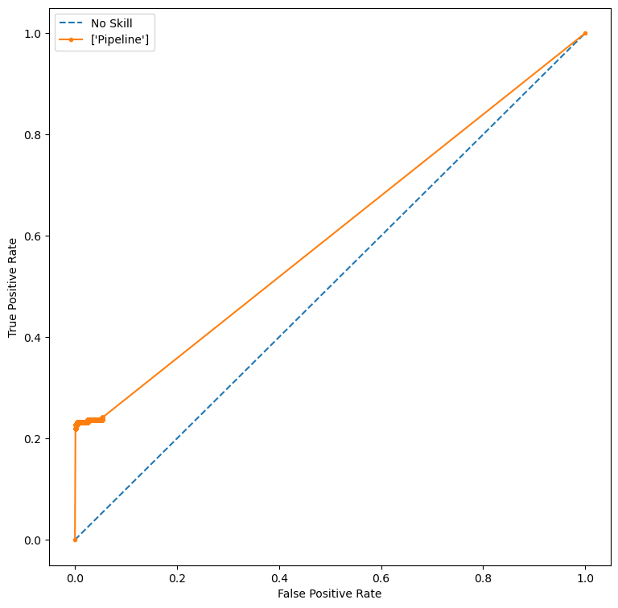

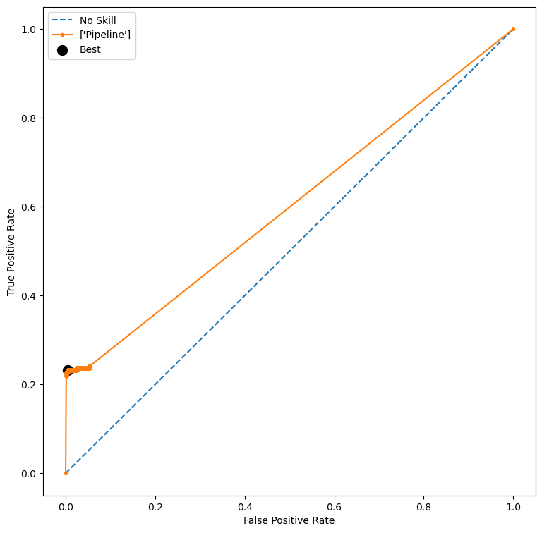

```
ROC-AUC score of the model: 0.5997178026957919
Accuracy of the model: 0.9948215435233532

Classification report:
              precision    recall  f1-score   support

           0       1.00      1.00      1.00    209487
           1       0.05      0.23      0.09       228

    accuracy                           0.99    209715
   macro avg       0.53      0.61      0.54    209715
weighted avg       1.00      0.99      1.00    209715


Confusion matrix:
[[208577    910]
 [   176     52]]
```

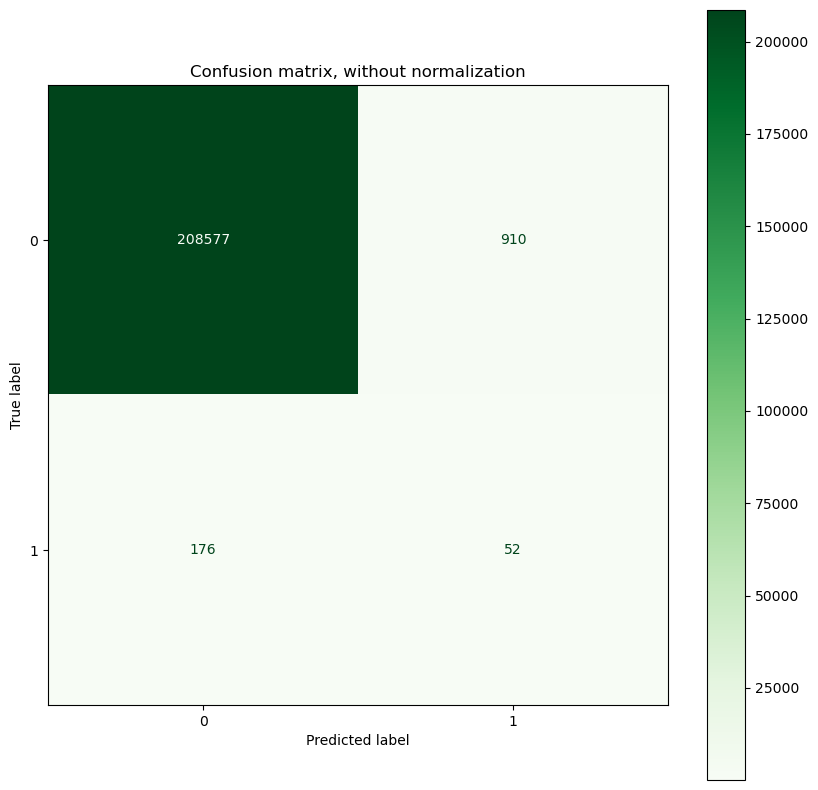

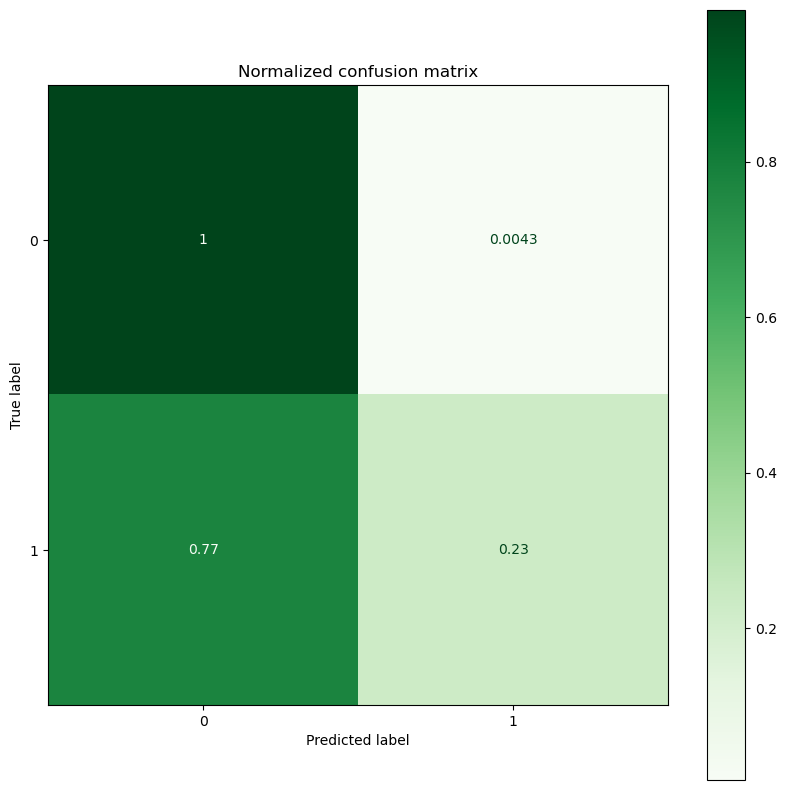

```python
model_analysis(lightgbm, xtest, ytest)
```

El modelo de lightGBM no es un modelo bueno. Matrix de confusion nos enseña los falsos negativos tienen 77%. comparando con otros modelos no vamos a optimizar

## ADABoost

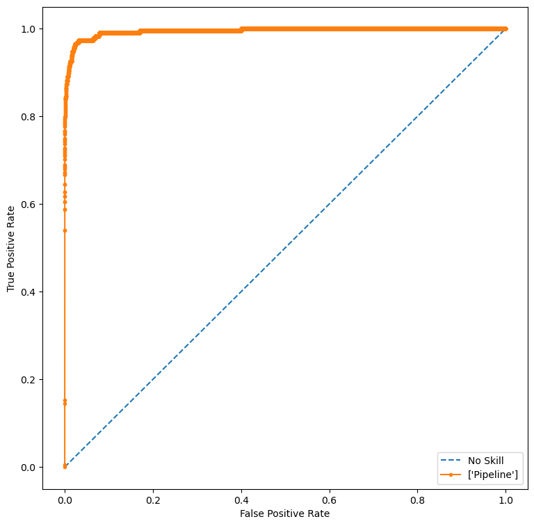

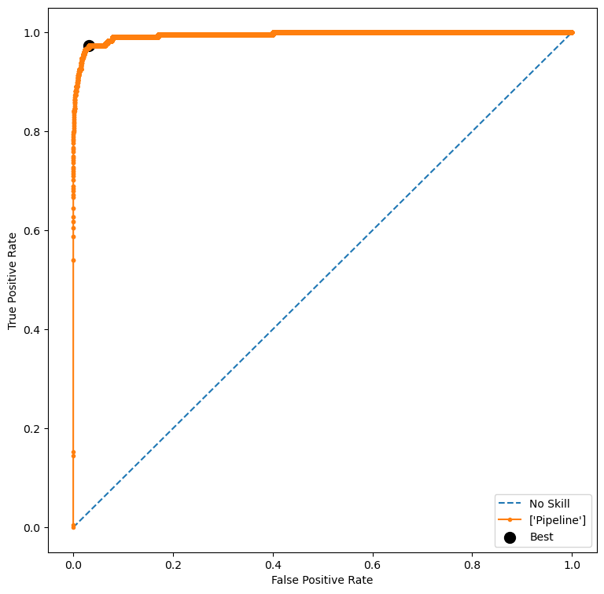

```
ROC-AUC score of the model: 0.9946321356121499
Accuracy of the model: 0.9689340295162483

Classification report:
              precision    recall  f1-score   support

           0       1.00      0.97      0.98    209487
           1       0.03      0.97      0.06       228

    accuracy                           0.97    209715
   macro avg       0.52      0.97      0.52    209715
weighted avg       1.00      0.97      0.98    209715


Confusion matrix:
[[202979   6508]
 [     7    221]]
```

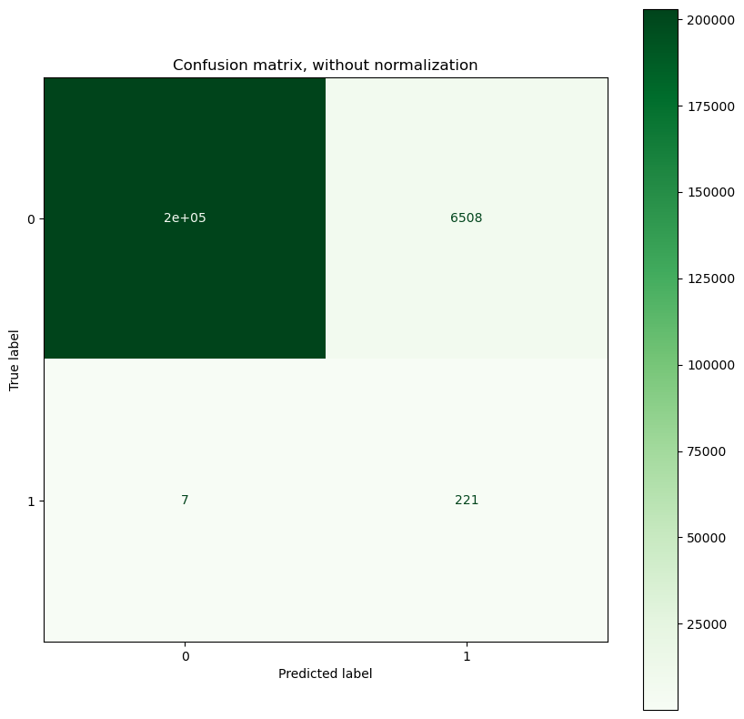

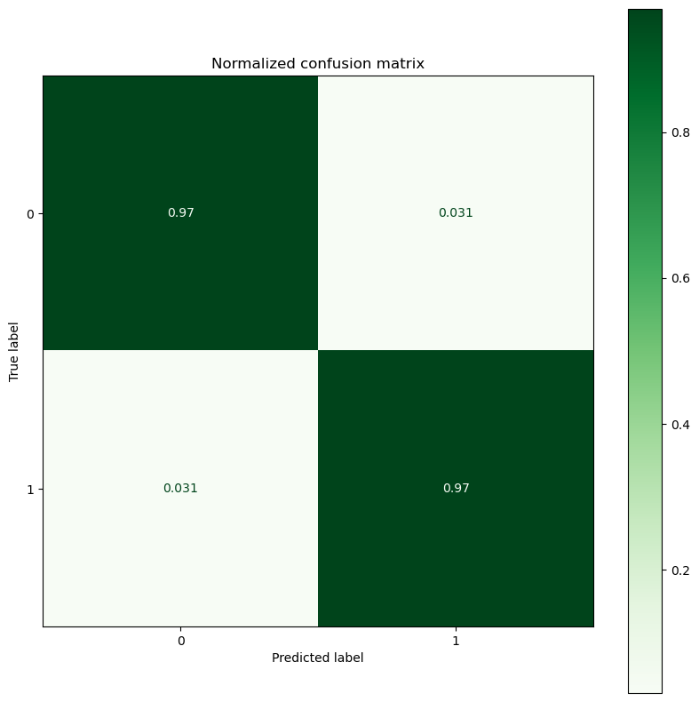

```python
model_analysis(adaboost, xtest, ytest)
```

El modelo de AdaBoost tambien tienen buenos resultados de ROC-AUC, Accuracy y valores de matrix de confusion. Podemos considerar para optimizar

## Decisión

Considerando metricas Accuracy, Matrix de Confusion y ROC-AUC Curve, nos sale bien los modelos Random Forest, AdaBoost y XGBoost. Estos modelos se puede optimizar